# 105181373_stats102a_hw1

zhengxing zhang

2020/1/21

```r
source('105181373_stats102a_hw1.R')
```

### function gcd

calculates greatest common of two numbers divisor using the Euclidean algorithm.

1. Input (a, b)
   1. **a**: positive integer and dimension = 1
   2. **b**: positive integer and dimension = 1
2. check both numbers whether is numerical. [**if** (is.numeric(a) | is.numeric(b) == FALSE)]
   1. (if) one or two of them is not numerical number -> stop with an error message
   2. (else) go to next step
3. check both numbers whether is positive integer. [**if** (a <= 0 | b <= 0 | a%%1 != 0 | b%%1 != 0)]
   1. (if) one or two of them is not positive integer -> stop with an error message
   2. (else) go to next step
4. use **while (b != 0)** loop
   1. using the Euclidean algorithm.
   2. change (a, b) -> (b, a%%b) again and again
   3. when b = 0 end
5. after the while loop, we get (a<- the greatest common divisor, b<-0).
   1. return (a), which is output
   2. output is a positive integer.

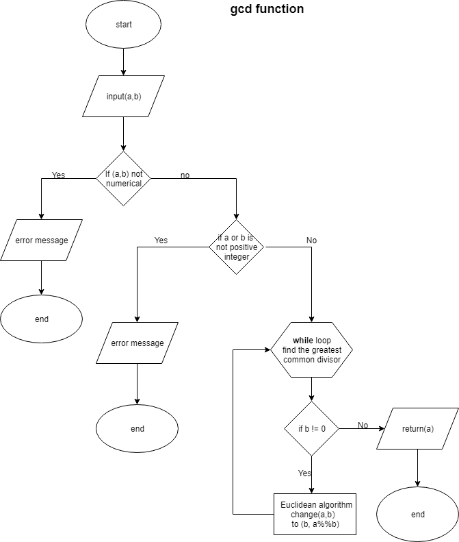

gcd_flowchart

```r
gcd(1071, 462)
```

```
## [1] 21
```

```r
gcd(462, 1071)
```

```
## [1] 21
```

```r
gcd(646,1406)
```

```
## [1] 38
```

```r
gcd(1,10)
```

```
## [1] 1
```

```r
try(gcd(0, 12))
```

```
## Error in gcd(0, 12) : inputs should be positive integers
```

```r
try(gcd(4.5, 12))
```

```
## Error in gcd(4.5, 12) : inputs should be positive integers
```

```r
try(gcd(-1, 12))
```

```
## Error in gcd(-1, 12) : inputs should be positive integers
```

### gcd_three

calculates greatest common of three numbers divisor using the Euclidean algorithm.

1. input(a, b, c)
   1. **a**: positive integer and dimension = 1
   2. **b**: positive integer and dimension = 1
   3. **c**: positive integer and dimension = 1
2. use gcd function we create before
   1. find the greatest common divisor of (a, b), and store in a new variable named cd_two. [cd_two = **gcd(a,b)**]
3. use gcd function we create before
   1. find the greatest common divisor of (new variable, c). [**gcd(c,cd_two)**]
   2. then we return the greatest divisor of (a, b, c).
   3. output: positive integer.

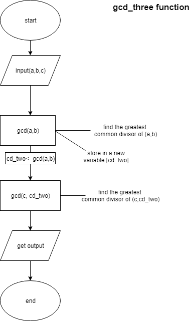

gcd_three_flowchart

```r
gcd_three(1071, 462, 4452)
```

```
## [1] 21
```

```r
gcd_three(646, 1406, 4218)
```

```
## [1] 38
```

### is_prime

check all number whether is prime

1. input(x)
   1. **x**: atomic vector and dimension = 1
   2. get the length of x
   3. create a return variable and named “output”
2. use **for (i in 1:x_len)** loop, check every number of x, use x[i].
   1. check number whether is positive integer. [**if** (x[i] <= 0 | x[i]%%1 != 0)]
      1. (if) number is not positive integer, return FALSE
      2. (else) go to next step
   2. check number whether is 2. [**if** (x[i] == 2)]
      1. (if) number is 2, return TRUE
      2. (else) go to next step
   3. use **for (j in 2:b)** loop, check there is any divisor in 2:b. (b<- x[i] – 1)
      1. (if) there exist a divisor(not prime),
      2. then return False. Break the loop.

      3. ```
         (else) return true and check next number in 2:b
         ```

3. After checking all the number, return the output
   1. Return: logical vector and dimension = 1

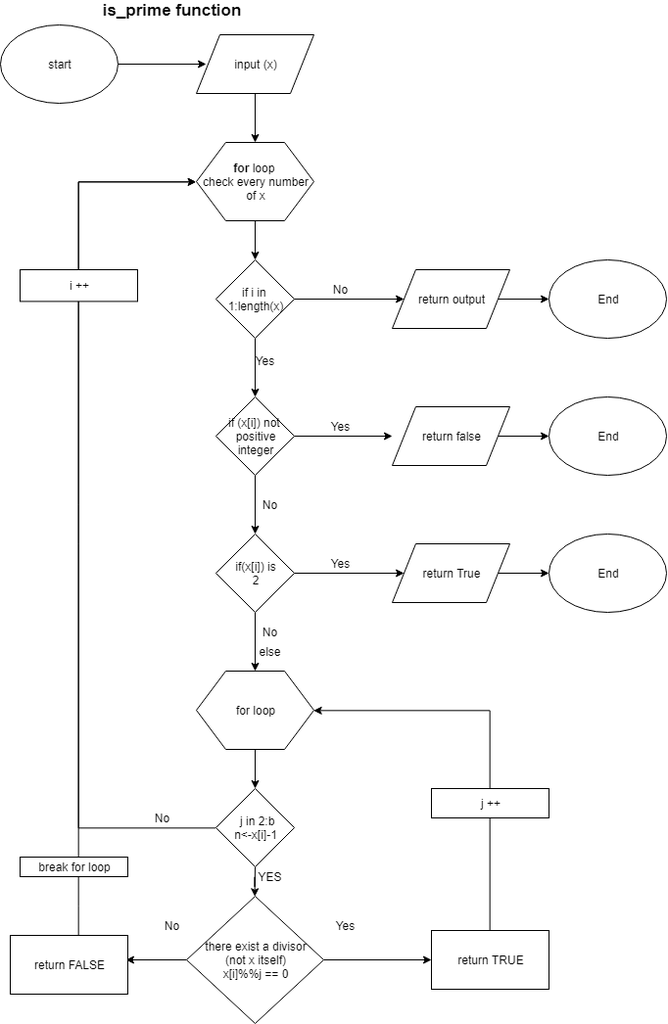

is_prime_flowchart

```r
is_prime(9)
```

```
## [1] FALSE
```

```r
is_prime(c(2,97,23,51,119, -1, 0,1.5))
```

```
## [1]  TRUE  TRUE  TRUE FALSE FALSE FALSE FALSE FALSE
```

### get_factors

Find all prime factors of x

1. Input(x)
   1. **x**: atomic vector and dimension = 1
   2. store x to a test variable n
   3. create a return variable and named “output_prime”
2. check the number whether is numerical. [**if** (is.numeric(n) == FALSE)]
   1. (if) it is not numerical number -> stop with an error message
   2. (else) go to next step
3. check the number whether is positive integer. [**if** (n <= 0 | n%%1 != 0)]
   1. (if) it is not positive integer -> stop with an error message
   2. (else) go to next step
4. check the number whether is 1. [**if** (n == 1)]
   1. (if) it is 1 -> stop with an error message
   2. (else) go to next step
5. check the number whether is prime number. [**if** (is_prime(n) == TRUE)]
   1. (if) it is prime number -> return itself
   2. (else) go to next step, find the prime factors of x
6. use **while (j <= n)** loop, and let j = 2. Checking if there exists a prime factor between 2 and n.
   1. (if) j is a prime factor between j and n.
      1. store j into output_prime. [output_prime <- append(output_prime, j)]
      2. get a new n <- n/j and store to n. so we can find another prime factor.
   2. check next j. [j <- j + 1]
7. After checking all the prime factor
   1. return the output_prime
   2. output: positive integer and dimension = 1

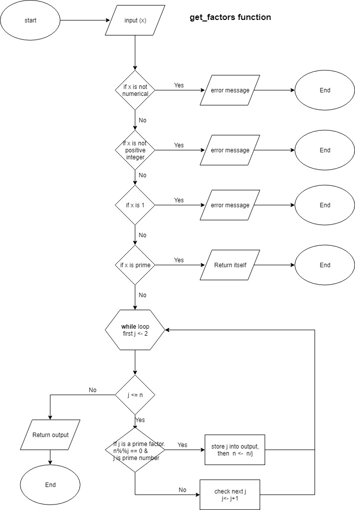

get_factors_flowchart

```r
get_factors(12)
```

```
## [1] 2 2 3
```

```r
get_factors(1800)
```

```
## [1] 2 2 2 3 3 5 5
```

```r
get_factors(32851)
```

```
## [1]  7 13 19 19
```

```r
get_factors(9587)
```

```
## [1] 9587
```

```r
try(get_factors(-280))
```

```
## Error in get_factors(-280) : input should be positive integer
```

```r
try(get_factors(280.75))
```

```
## Error in get_factors(280.75) : input should be positive integer
```

```r
x <- sample(x = 1e4, size = 1)
y <- get_factors(x)
this_works <- prod(y) == x & all(is_prime(y))
this_works
```

```
## [1] TRUE
```